# Part iA: Predictors (categorical)

INFSCI 2595 Final

Ben Stein

4/27/2022

# About this document

In this document, I perform exploratory data analysis on the categorical predictors (`customer` and `region`).

# Setup

## Libraries and tools

```r
library(tidyverse)
source("./tools.R")
```

## Data

```r
df <- load_project_data(convert_categoricals = TRUE, response_to_log = FALSE)
df %>% glimpse()
```

```
## Rows: 677
## Columns: 37
## $ region          <fct> XX, XX, XX, XX, XX, XX, XX, XX, XX, XX, XX, XX, XX, XX~
## $ customer        <fct> B, B, B, B, B, B, B, B, B, B, B, B, B, B, B, B, B, B, ~
## $ xb_01           <dbl> 4.000000, 1.000000, 2.000000, 2.520000, 2.548387, 3.07~
## $ xb_02           <dbl> 4, 1, 2, 11, 6, 6, 10, 12, 9, 10, 8, 10, 10, 8, 6, 10,~
## $ xb_03           <dbl> 4, 1, 2, -6, -1, 1, -4, -4, -2, -4, -2, -2, -2, -4, 1,~
## $ xn_01           <dbl> 3.0000000, 2.0000000, 2.0000000, 1.5333333, 0.8387097,~
## $ xn_02           <dbl> 3, 2, 4, 9, 3, 8, 6, 10, 10, 4, 6, 8, 9, 5, 7, 12, 12,~
## $ xn_03           <dbl> 3, 2, 0, -3, -4, -2, -5, -6, -3, -5, -3, -6, -4, -3, 0~
## $ xa_01           <dbl> 12.000000, 3.000000, 9.000000, 7.080000, 6.451613, 6.8~
## $ xa_02           <dbl> 12, 3, 9, 29, 17, 18, 24, 27, 20, 19, 15, 24, 24, 15, ~
## $ xa_03           <dbl> 12, 3, 9, -7, -2, 2, -9, -5, -3, -3, -1, 1, -2, -3, 3,~
## $ xb_04           <dbl> 1.3333333, 1.0000000, 1.0000000, 0.8950476, 1.2247312,~
## $ xb_05           <dbl> 1.3333333, 1.0000000, 1.0000000, -2.0000000, -0.500000~
```

[output cut: 24 more lines]

# Exploratory data analysis

## The `customer` predictor

Let’s take a look at possible values for the `customer` categorical predictor and their distribution:

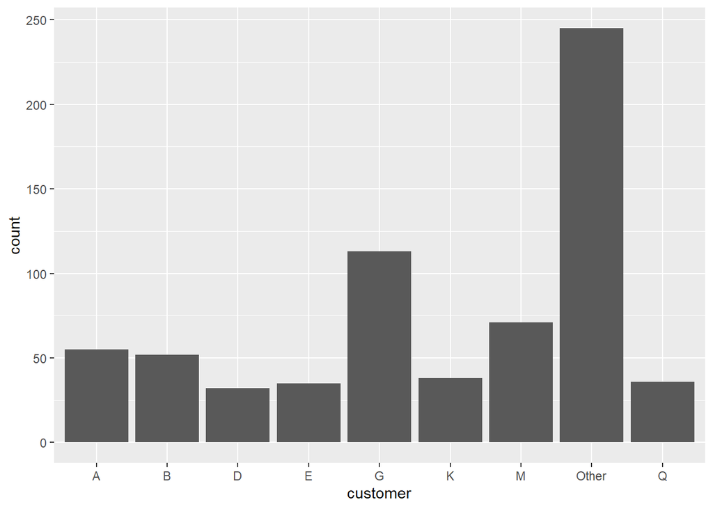

```r
df %>%
  select(customer) %>%
  ggplot(mapping = aes(x = customer)) +
  geom_histogram(stat = "count")
```

Key takeaways here are that there aren’t many unique values for the predictor (9) and that one category (“Other”) contains significantly more observation than others.

## The `region` predictor

Similarly, we can start by looking at the distribution of `region` values.

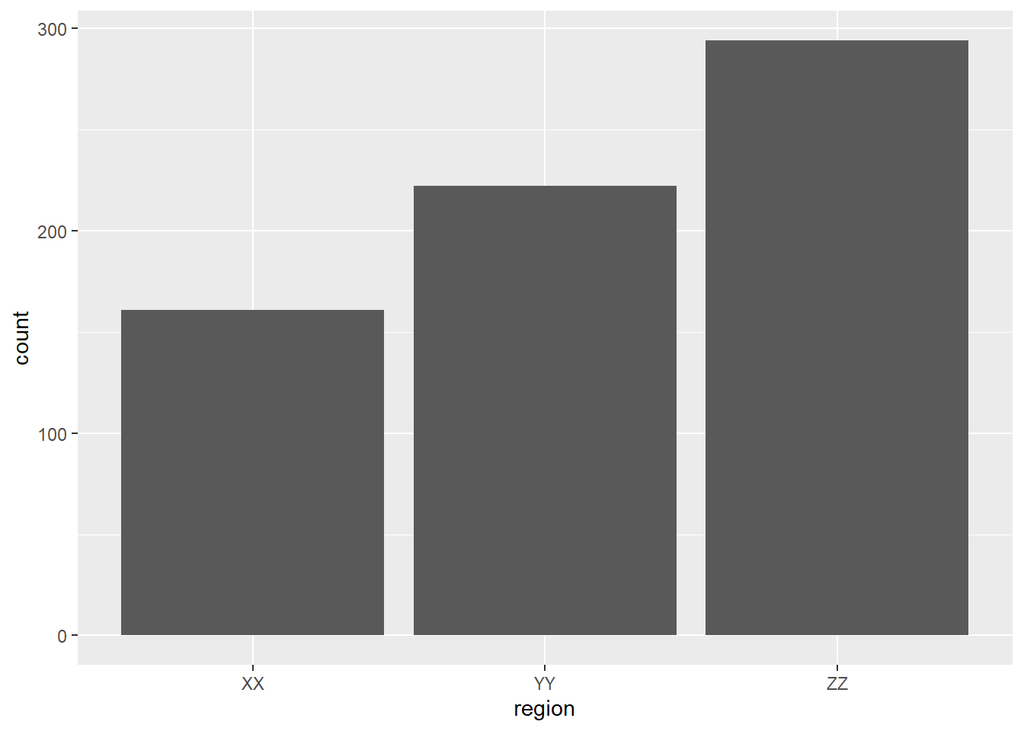

```r
df %>%
  select(region) %>%
  ggplot(mapping = aes(x = region)) +
  geom_histogram(stat = "count")
```

This factor has even fewer levels (only 3). However, unlike `customer`, the levels are more slightly more similar, with `ZZ` having the most values but the others not terribly far behind.

## Combinations of the categoricals

Let’s look at the distribution of these factors together.

**NOTE:** This concept and some of the code to make it happen is borrowed from the airfoil EDA example posted on Canvas for this course.

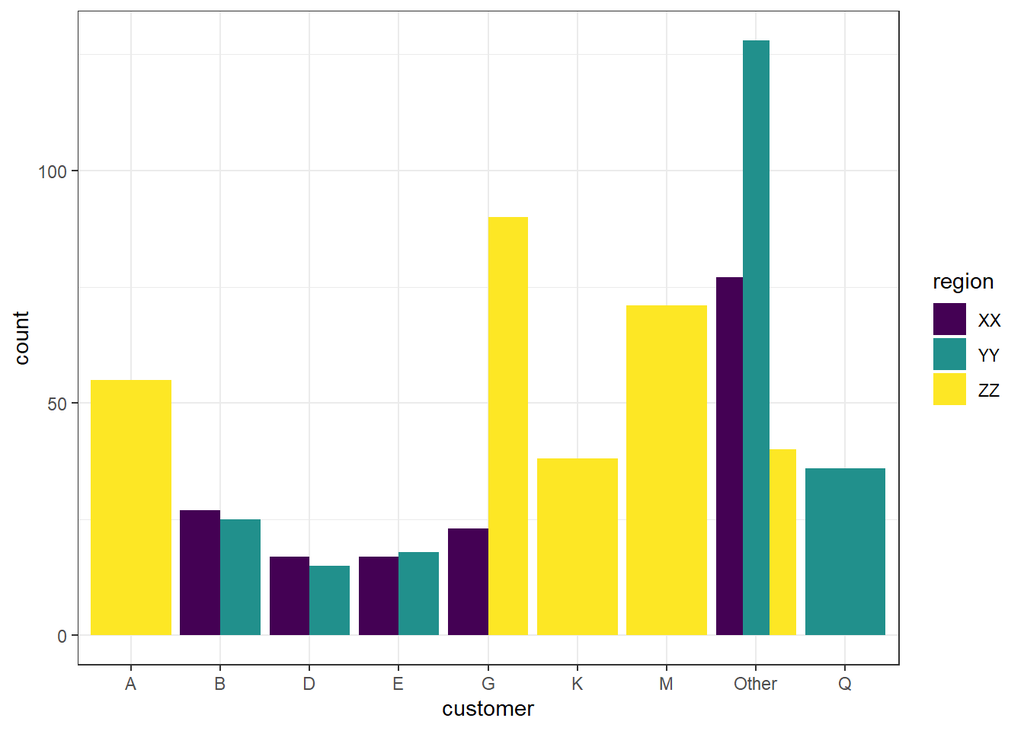

```r
df %>%
  ggplot(mapping = aes(x = customer)) +
  geom_bar(mapping = aes(fill = region), position = "dodge") +
  scale_fill_viridis_d("region") +
  theme_bw()
```

This reveals some interesting insights. First, the only level of `customer` that contains every region is `"Other"`, and regions `ZZ` and `YY` never appear in the same level of `customer` except for `"Other"`. Some `customer` levels appear in only one region.

After horsing around with this (and **borrowing more code from the airfoil EDA example**, I realized this can be better explained with a heatmap):

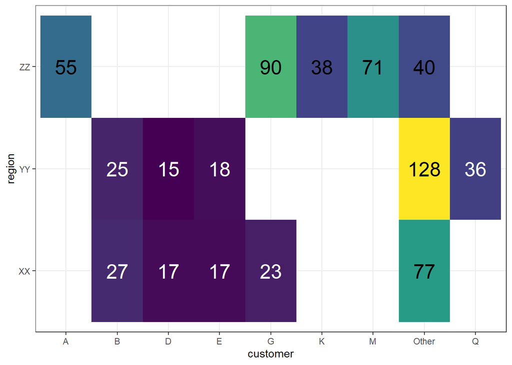

```r
df %>%
  count(customer, region) %>%
  ggplot(mapping = aes(x = customer, y = region)) +
  geom_tile(mapping = aes(fill = n)) +
  geom_text(mapping = aes(label = n,
                          color = n > median(n)),
            size = 7) +
  scale_fill_viridis_c(guide = 'none') +
  scale_color_manual(guide = 'none',
                     values = c("TRUE" = 'black',
                                "FALSE" = 'white')) +
  theme_bw()
```